# Lecture 09 Correlation and Regression

Author

Bill Perry

# Lecture 8: Review

Covered

- Study design
- Causality in ecology
- Experimental design:
  - Replication, controls, randomization, independence
- Sampling in field studies
- Power analysis: *a priori* and *post hoc*
- Study design and analysis

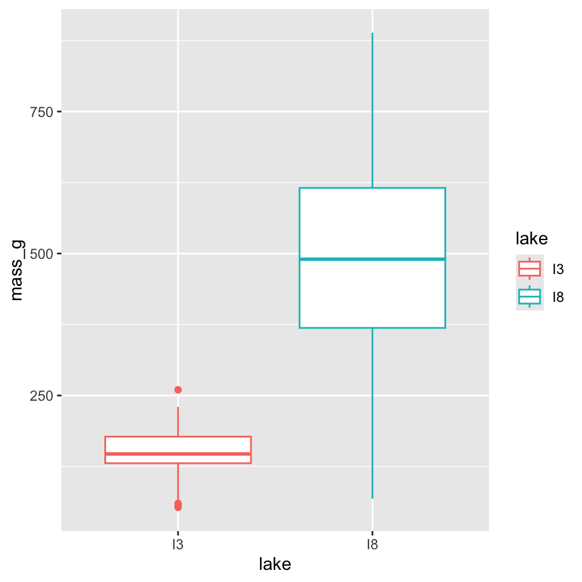

# **Lecture 9:** Overview

### The objectives:

This lecture covers two fundamental statistical techniques in biology: correlation and regression analysis. Based on Chapters 16-17 from Whitlock & Schluter’s *The Analysis of Biological Data* (3rd edition), we’ll explore:

- Correlation analysis: measuring relationships between variables
- The distinction between correlation and regression
- Simple linear regression: predicting one variable from another
- Estimating and interpreting regression parameters
- Testing assumptions and handling violations
- Analysis of variance in regression
- Model selection and comparison

# **Lecture 9:** Correlation vs. Regression:

### **Correlation Analysis:**

- Measures the strength and direction of a relationship between two numerical variables
- Both X and Y are random variables (both measured, neither manipulated)
- Variables are typically on equal footing (either could be X or Y)
- No cause-effect relationship implied
- Quantifies the degree to which variables are related
- Expressed as a correlation coefficient (r) from -1 to +1

### **Regression Analysis:**

- Predicts one variable (Y) from another (X)
- X is often fixed or controlled (manipulated)
- Y is the response variable of interest
- Often implies a cause-effect relationship
- Produces an equation for prediction with slope and intercept parameters

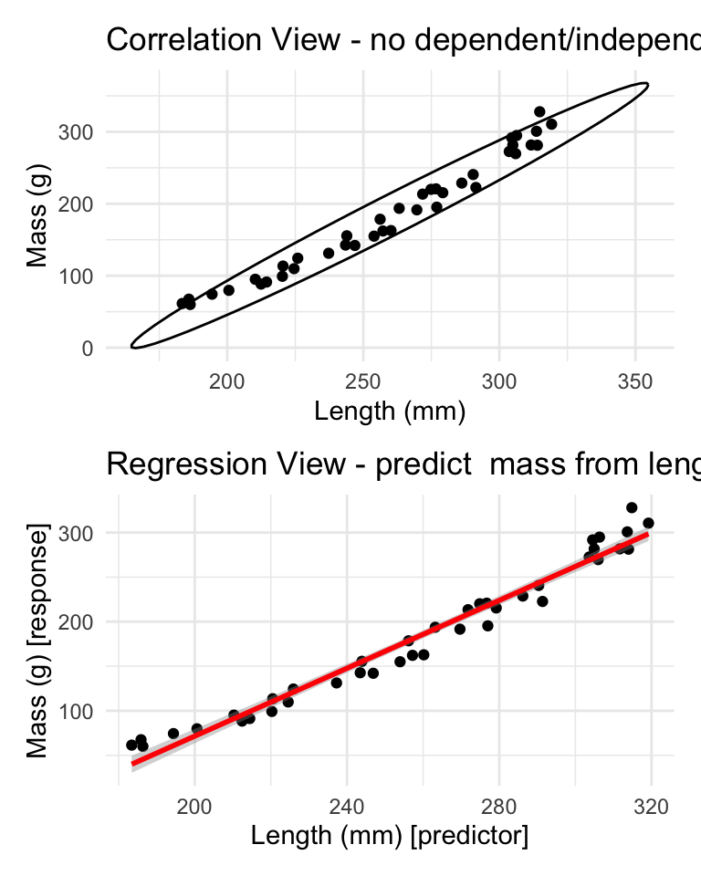

# **Lecture 9:** Correlation Analysis

### What Is Correlation?

**Correlation analysis** measures the strength and direction of a relationship between two numerical variables:

- Ranges from -1 to +1
- +1 indicates perfect positive correlation
- 0 indicates no correlation
- -1 indicates perfect negative correlation

The **Pearson correlation coefficient (r)** is defined as:

$$r = \frac{\sum_{i}(X_i - \bar{X})(Y_i - \bar{Y})}{\sqrt{\sum_{i}(X_i - \bar{X})^2 \sum_{i}(Y_i - \bar{Y})^2}}$$

This can be simplified as:

$$r = \frac{\text{Covariance}(X, Y)}{s_X \cdot s_Y}$$

Where $s_X$ and $s_Y$ are the standard deviations of X and Y.

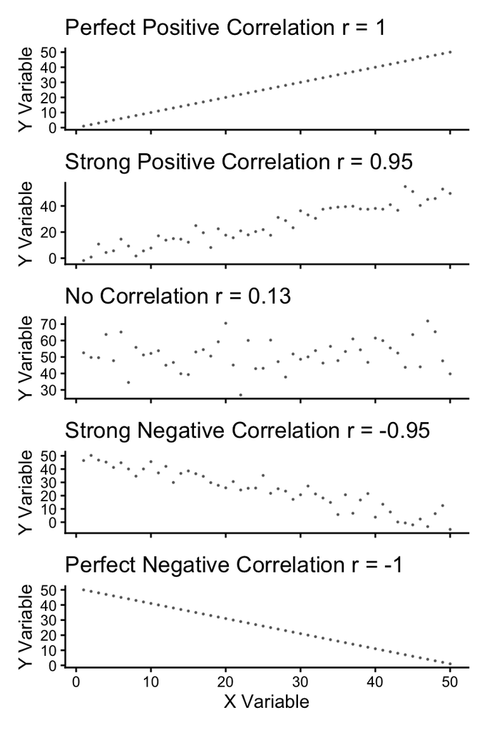

# **Lecture 9:** Correlation Analysis

### Example 16.1: Flipping the Bird

Nazca boobies (*Sula granti*) - Do aggressive behaviors as a chick predict future aggressive behavior as an adult?

- correlation is r = 0.534 - moderate positive relationship
- p-value = 0.007 correlation is statistically significant.

For a Pearson correlation coefficient (r) of 0.53372:

- This is r (not rho as Spearman nonparametric below), as indicated by “cor” in your output
- To determine the amount of variation explained, you square this value: r² = 0.53372² = 0.2849 (or approximately 28.49%)
- means about 28.49% of the variance in one variable can be explained by the other variable

### Note that it is tested by a t test: $\text{t}=\frac{r}{SE_r}$

```
    Pearson's product-moment correlation

data:  booby_data$visits_as_nestling and booby_data$future_aggression
t = 2.9603, df = 22, p-value = 0.007229
alternative hypothesis: true correlation is not equal to 0
95 percent confidence interval:
 0.1660840 0.7710999
sample estimates:
      cor
0.5337225
```

# **Lecture 9:** Correlation Analysis

### Example 16.1: Flipping the Bird

**Interpretation:** The correlation coefficient of r = 0.534 suggests that Nazca boobies who experienced more visits from non-parent adults as nestlings tend to display more aggressive behavior as adults. This supports the hypothesis that early experiences influence adult behavior patterns in this species.

**Standard Error:**

### $\text{SE}_r = \sqrt{\frac{1-r^2}{n-2}}$

### SE = 0.180

Need to be sure relationship is not curved - note below

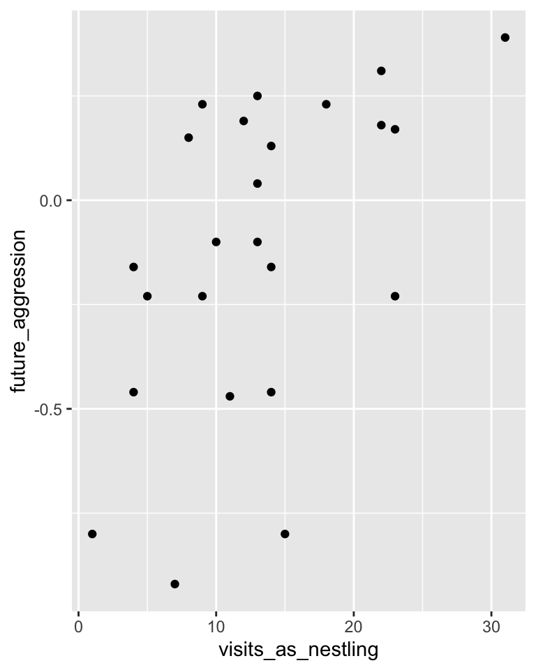

# **Lecture 9:** Correlation Analysis

### Testing Assumptions for Correlation

As described in Section 16.3, correlation analysis has key assumptions:

1. **Random sampling**: Observations should be a random sample from the population
2. **Bivariate normality**: Both variables follow a normal distribution, and their joint distribution is bivariate normal
3. **Linear relationship**: The relationship between variables is linear, not curved

Let’s check these assumptions booby data:

```
    Shapiro-Wilk normality test

data:  booby_data$visits_as_nestling
W = 0.95783, p-value = 0.3965
```

```
    Shapiro-Wilk normality test

data:  booby_data$future_aggression
W = 0.91575, p-value = 0.04709
```

# **Lecture 9:** Correlation Analysis

### Testing Assumptions for Correlation

As described in Section 16.3, correlation analysis has key assumptions:

1. **Random sampling**: Observations should be a random sample from the population
2. **Bivariate normality**: Both variables follow a normal distribution, and their joint distribution is bivariate normal
3. **Linear relationship**: The relationship between variables is linear, not curved

Let’s check these assumptions using the booby data

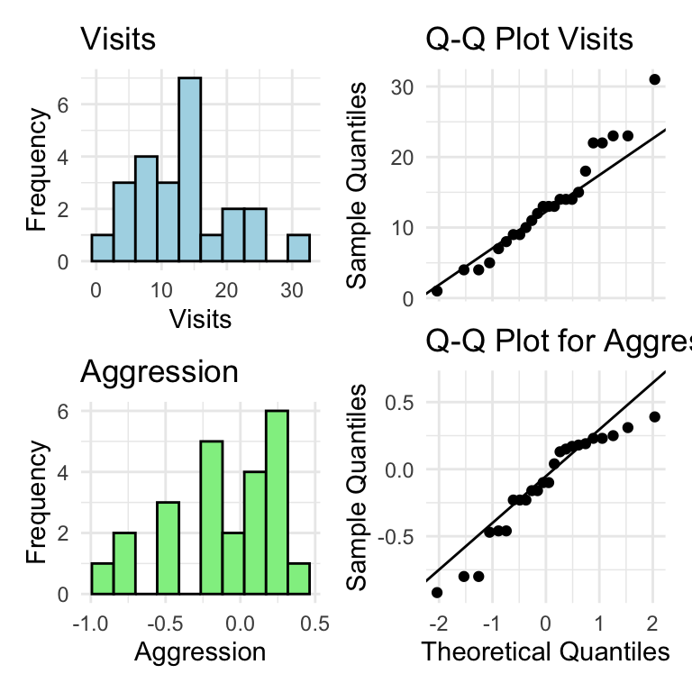

# **Lecture 9:** Correlation Analysis

### **What to do if assumptions are violated:**

Transform one or both variables (log, square root, etc.)

Use non-parametric correlation (**Spearman’s rank correlation**) or Kendall’s tau 𝛕

Examine the data for outliers or influential points

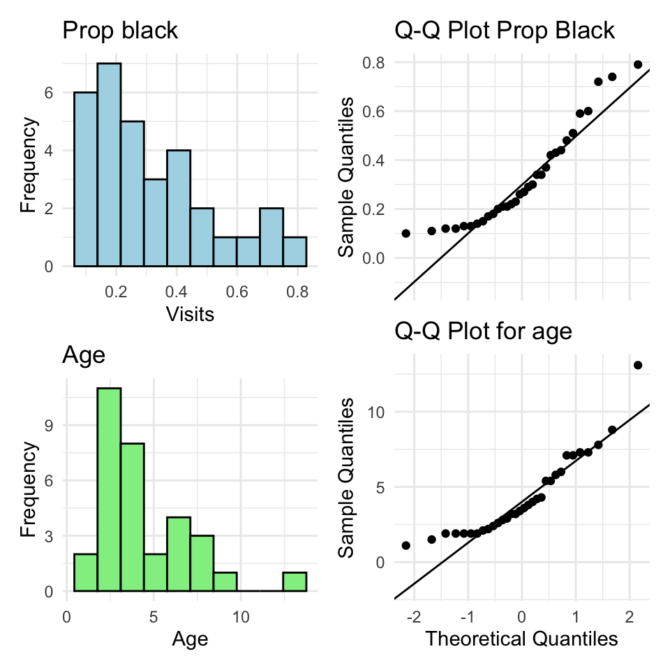

# **Lecture 9:** Correlation Analysis

To understand the amount of variation explained, you can square the non parametric Spearman’s rho value.

For your value of 0.74485:

ρ² = 0.74485² = 0.5548

This means approximately 55.48% of the variance in ranks of one variable can be explained by the ranks of the other variable. This is similar to how R² works in linear regression, but specifically for ranked data.

```
    Spearman's rank correlation rho

data:  lion_data$proportion_black and lion_data$age_years
S = 1392.1, p-value = 1.013e-06
alternative hypothesis: true rho is not equal to 0
sample estimates:
      rho
0.7448561
```

# **Lecture 9:** Correlation Analysis

### Correlation: Important Considerations

- **The correlation coefficient depends on the range**
  - Restricting range of values can reduce the correlation coefficient
  - Comparing correlations between studies requires similar ranges of values
- **Measurement error affects correlation**
  - Measurement error in X or Y tends to weaken observed correlation
  - This bias is called **attenuation**
  - True correlation typically stronger than observed correlation
- **Correlation vs. Causation**
  - Correlation does not imply causation
  - Three possible explanations for correlation:
    1. X causes Y
    2. Y causes X
    3. Z (a third variable) causes both X and Y
- **Correlation significance test**
  - H₀: ρ = 0 (no correlation in population)
  - H₁: ρ ≠ 0 (correlation exists in population)
  - **Test statistic: t = r / SE(r) with df = n-2**

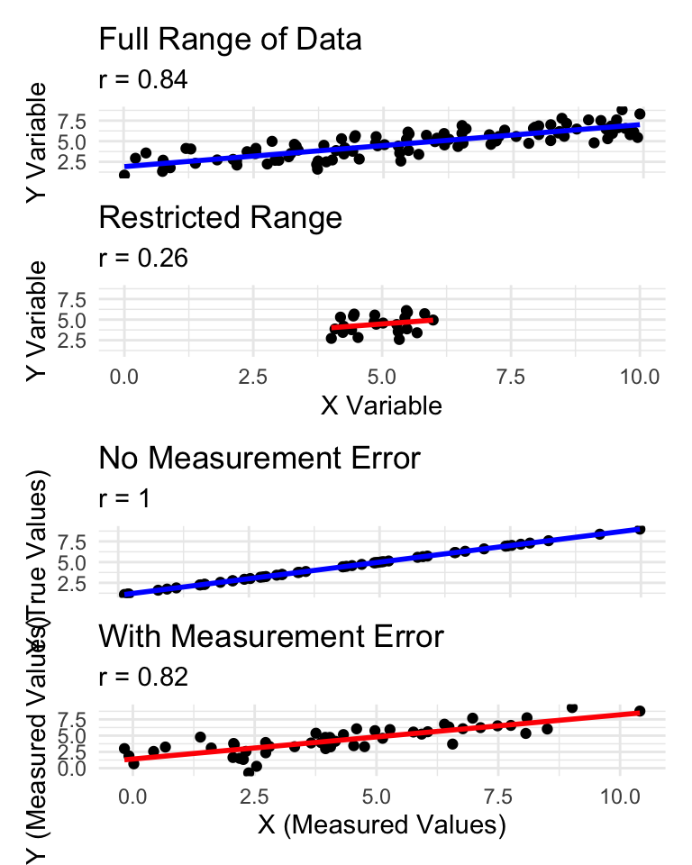

# **Lecture 9:** Linear Regression

### Simple Linear Regression Model

**Simple linear regression** models the relationship between a response variable (Y) and a predictor variable (X).

The **population** regression model $Y = \alpha + \beta X + \varepsilon$

- Where:
  - Y is the response variable
  - X is the predictor variable
  - α (alpha) is the intercept (value of Y when X=0)
  - β (beta) is the slope (change in Y per unit change in X)
  - ε (epsilon) is the error term (random deviation from the line)

The **sample** regression equation is: $\hat{Y} = a + bX$

- Where:
  - $\hat{Y}$ is the predicted value of Y
  - a is the estimate of α (intercept)
  - b is the estimate of β (slope)

**Method of Least Squares**: The line is chosen to minimize the sum of squared vertical distances (residuals) between observed and predicted Y values.

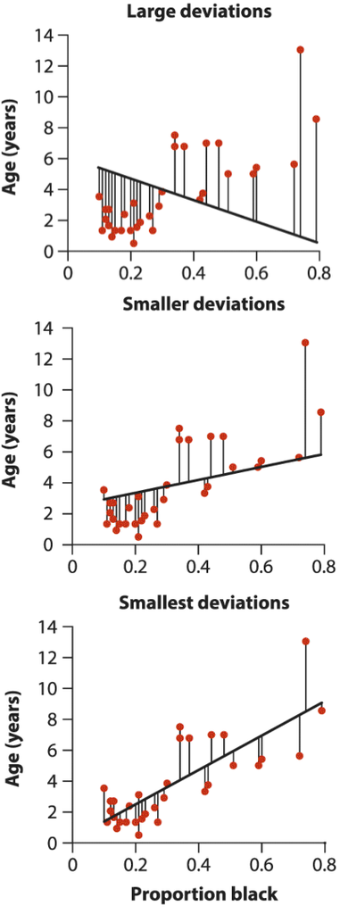

# **Lecture 9:** Linear Regression

### Simple Linear Regression Model

**Simple linear regression** models the relationship between a response variable (Y) and a predictor variable (X).

The **population** regression model is: $Y = \alpha + \beta X + \varepsilon$

- Where:
  - Y is the response variable
  - X is the predictor variable
  - α (alpha) is the intercept (value of Y when X=0)
  - β (beta) is the slope (change in Y per unit change in X)
  - ε (epsilon) is the error term (random deviation from the line)

The **sample** regression equation is: $\hat{Y} = a + bX$

- Where:
  - $\hat{Y}$ is the predicted value of Y
  - a is the estimate of α (intercept)
  - b is the estimate of β (slope)

**Method of Least Squares**: The line is chosen to minimize the sum of squared vertical distances (residuals) between observed and predicted Y values.

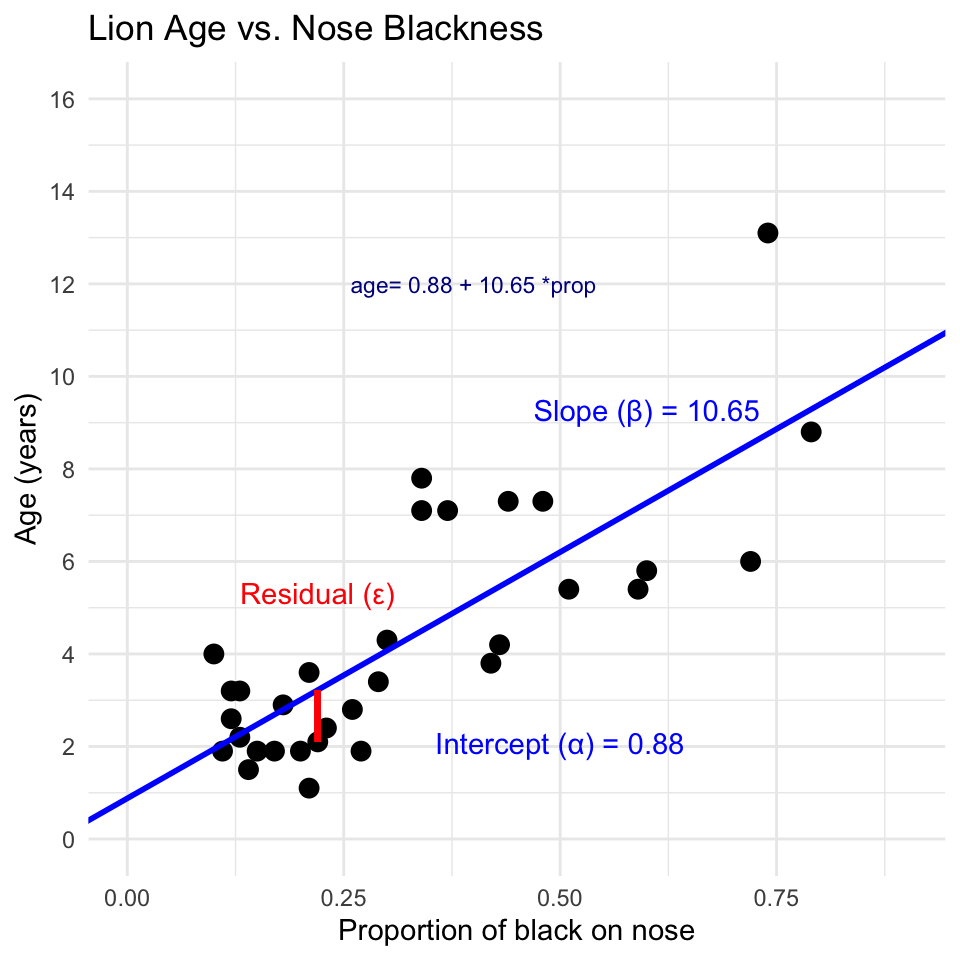

# **Lecture 9:** Linear Regression

From Example 17.1 in the textbook the regression line for the lion data is:

### $\text{age} = 0.88 + 10.65 \times \text{proportion}_{black}$

This means:

- When a lion has no black on its nose (proportion = 0), its predicted age is 0.88 years
- For each 0.1 increase in the proportion of black, age increases by 1.065 years
- The slope (10.65) indicates that lions with more black on their noses tend to be older

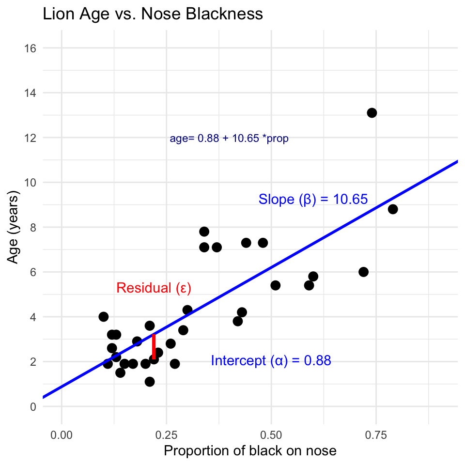

# **Lecture 9:** Linear Regression

### Simple Linear Regression Model

- male lions develop more black pigmentation on their noses as they age.
- can be used to estimate the age of lions in the field.

```
Call:
lm(formula = age_years ~ proportion_black, data = lion_data)

Residuals:
    Min      1Q  Median      3Q     Max
-2.5449 -1.1117 -0.5285  0.9635  4.3421

Coefficients:
                 Estimate Std. Error t value Pr(>|t|)
(Intercept)        0.8790     0.5688   1.545    0.133
proportion_black  10.6471     1.5095   7.053 7.68e-08 ***
---
Signif. codes:  0 '***' 0.001 '**' 0.01 '*' 0.05 '.' 0.1 ' ' 1

Residual standard error: 1.669 on 30 degrees of freedom
Multiple R-squared:  0.6238,    Adjusted R-squared:  0.6113
F-statistic: 49.75 on 1 and 30 DF,  p-value: 7.677e-08
```

# **Lecture 9:** Linear Regression

### Simple Linear Regression Model

The calculation for slope (m) is:
$$m = \frac{\sum_i(X_i - \bar{X})(Y_i - \bar{Y})}{\sum_i(X_i - \bar{X})^2}$$

- Given:
  - - $\bar{X} = 0.3222$
  - - $\bar{Y} = 4.3094$
  - - $\sum_i(X_i - \bar{X})^2 = 1.2221$
  - - $\sum_i(X_i - \bar{X})(Y_i - \bar{Y}) = 13.0123$

b = 13.0123 / 1.2221 = 10.647

Intercept (b): $b = \bar{Y} - m\bar{X} = 4.3094 - 10.647(0.3222) = 0.879$

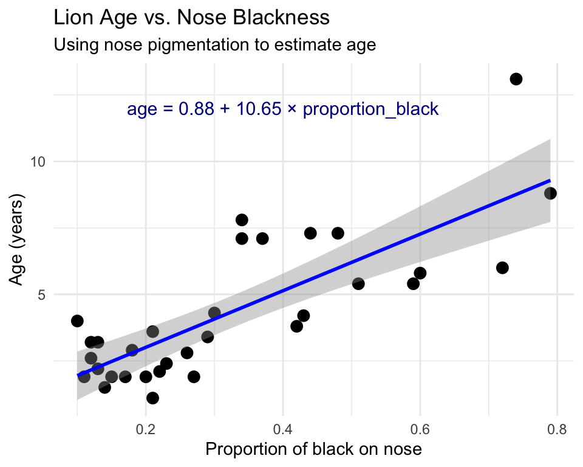

# **Lecture 9:** Linear Regression

### Simple Linear Regression Model

**Making predictions:**

To predict the age of a lion with 0.50 proportion of black on its nose:

$$\hat{Y} = 0.88 + 10.65(0.50) = 6.2 \text{ years}$$

**Confidence intervals vs. Prediction intervals:**

- **Confidence interval**: Range for the mean age of all lions with 0.50 black
- **Prediction interval**: Range for an individual lion with 0.50 black

Both intervals are narrowest near $\bar{X}$ and widen as X moves away from the mean.

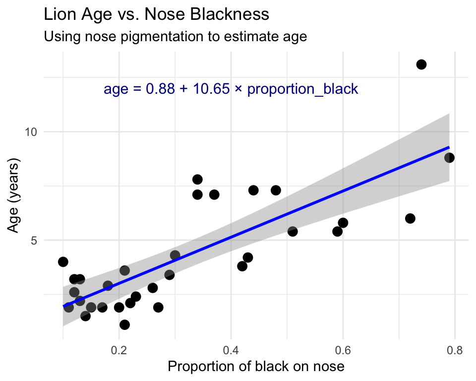

# **Lecture 9:** Linear Regression

### Example Prairie Home Companion

- Does biodiversity affect ecosystem stability?
- Tilman et al. (2006) investigated using experimental plots varying plant species

```
Call:
lm(formula = log_stability ~ species_number, data = prairie_data)

Residuals:
     Min       1Q   Median       3Q      Max
-0.82774 -0.25344 -0.00426  0.27498  0.75240

Coefficients:
               Estimate Std. Error t value Pr(>|t|)
(Intercept)    1.252629   0.041023  30.535  < 2e-16 ***
species_number 0.025984   0.004926   5.275 4.28e-07 ***
---
Signif. codes:  0 '***' 0.001 '**' 0.01 '*' 0.05 '.' 0.1 ' ' 1

Residual standard error: 0.3433 on 159 degrees of freedom
Multiple R-squared:  0.149, Adjusted R-squared:  0.1436
F-statistic: 27.83 on 1 and 159 DF,  p-value: 4.276e-07
```

```
Analysis of Variance Table

Response: log_stability
                Df  Sum Sq Mean Sq F value    Pr(>F)
species_number   1  3.2792  3.2792  27.829 4.276e-07 ***
Residuals      159 18.7358  0.1178
---
Signif. codes:  0 '***' 0.001 '**' 0.01 '*' 0.05 '.' 0.1 ' ' 1
```

# **Lecture 9:** Linear Regression

The hypothesis test asks whether the slope equals zero:

- H₀: β = 0 (species number does not affect stability)
- H₁: β ≠ 0 (species number does affect stability)

t = estimate/SE

**Interpretation:**

This supports the biodiversity-stability hypothesis: more diverse plant communities have more stable biomass production over time.

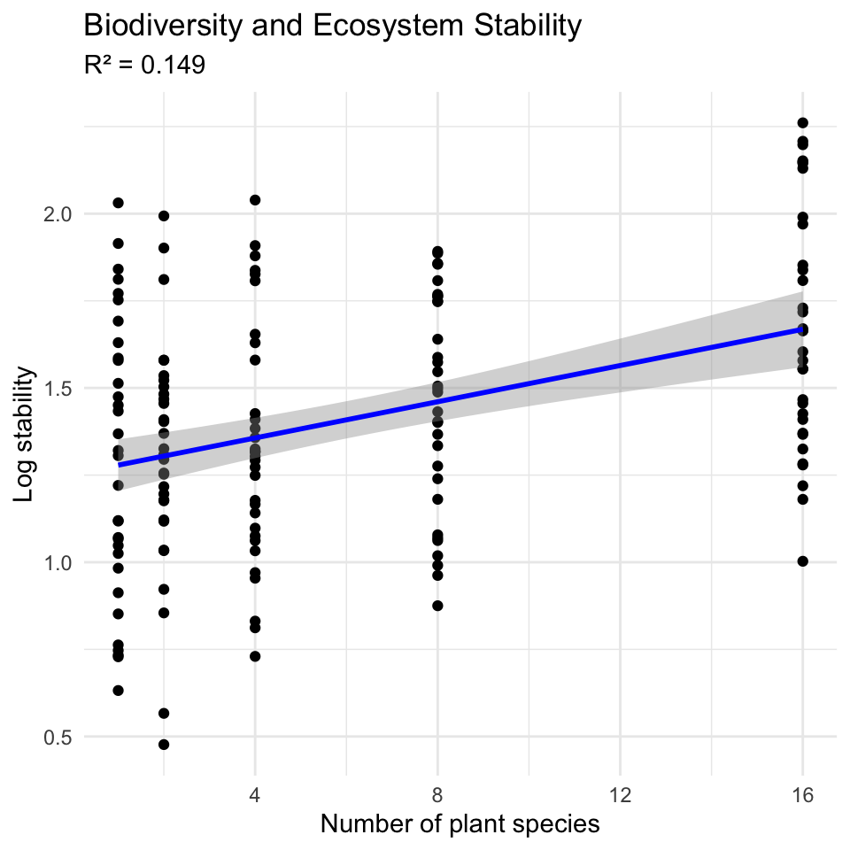

# **Lecture 9:** Linear Regression

### Testing Regression Assumptions

linear regression has four key assumptions:

1. **Linearity**: The relationship between X and Y is linear
2. **Independence**: Observations are independent
3. **Homoscedasticity**: Equal variance across all values of X
4. **Normality**: Residuals are normally distributed

Let’s check these assumptions for the lion regression model:  
Assume that **error 𝞮 i**s $e_i = y_i - \hat{y}_i$

- normally distributed for each x<sub>i</sub>
- has the same variance
- has a mean of 0 at each xi

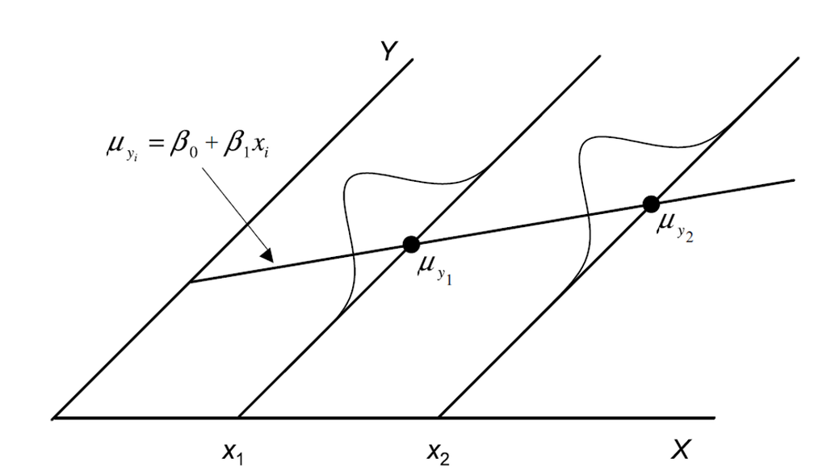

# **Lecture 9:** Linear Regression

### Testing Regression Assumptions

linear regression has four key assumptions:

1. **Linearity**: The relationship between X and Y is linear
2. **Independence**: Observations are independent
3. **Homoscedasticity**: Equal variance across all values of X
4. **Normality**: Residuals are normally distributed

Let’s check these assumptions for the lion regression model:  
Assume that **error 𝞮 i**s - estimated as the residuals: $e_i = y_i - \hat{y}_i$

- ordinary lease square estimates a and b or slope and intercept to minimize the sum of the residuals squared as

### $\sum_{i=1}^{n} = (y_i - \hat{y}_i)^2$

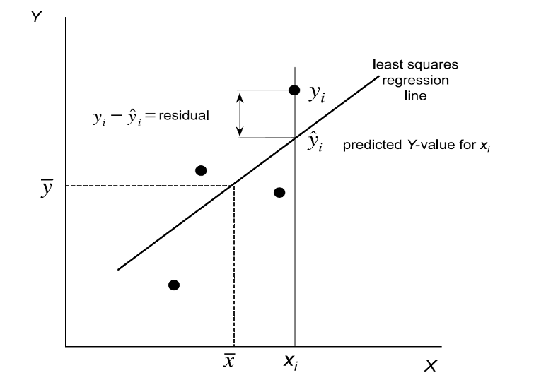

# **Lecture 9:** Linear Regression

### Testing Regression Assumptions

linear regression has four key assumptions:

1. **Linearity**: The relationship between X and Y is linear
2. **Independence**: Observations are independent
3. **Homoscedasticity**: Equal variance across all values of X
4. **Normality**: Residuals are normally distributed

Let’s check these assumptions for the lion regression model:

Linearity - how does this plot work

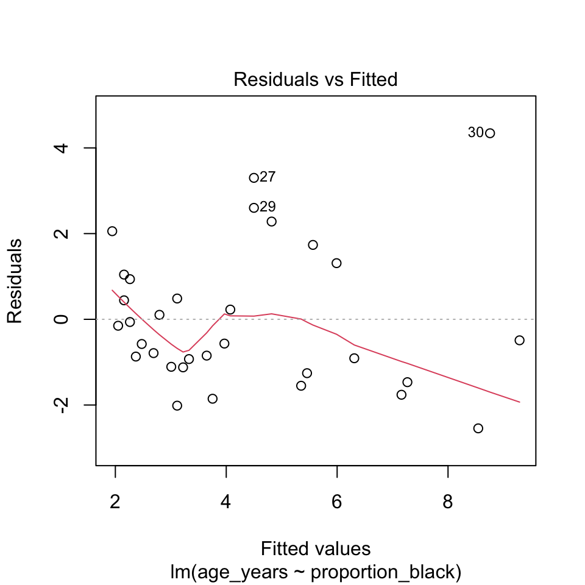

# **Lecture 9:** Linear Regression

### Testing Regression Assumptions

linear regression has four key assumptions:

1. **Linearity**: The relationship between X and Y is linear
2. **Independence**: Observations are independent
3. **Homoscedasticity**: Equal variance across all values of X
4. **Normality**: Residuals are normally distributed

Let’s check these assumptions for the lion regression model:

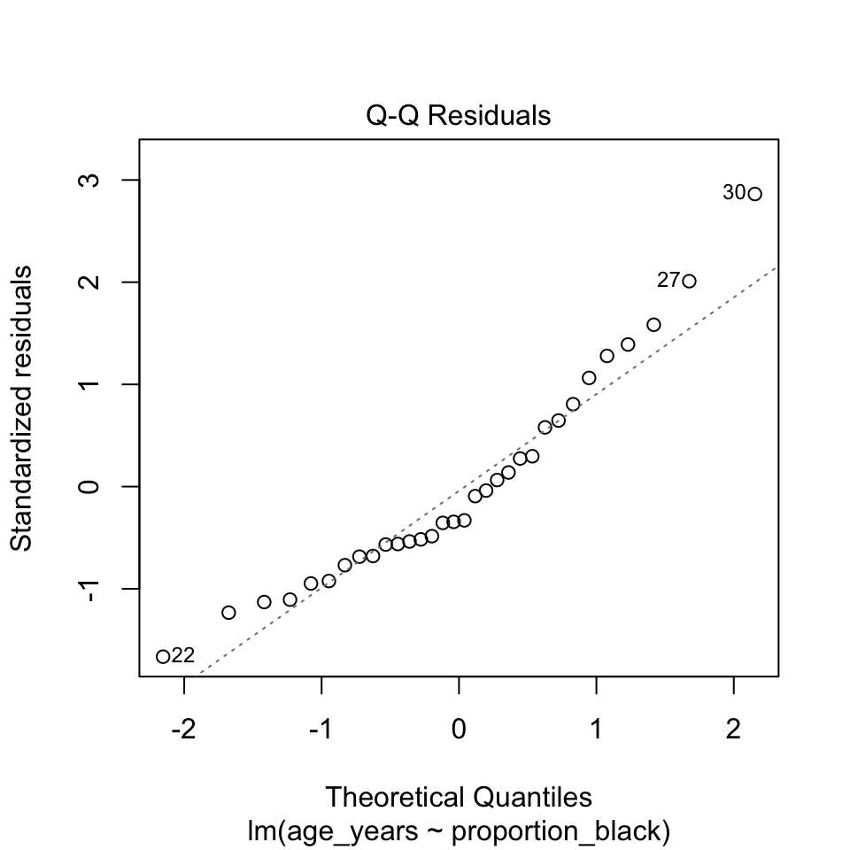

# **Lecture 9:** Linear Regression

### Testing Regression Assumptions

linear regression has four key assumptions:

1. **Linearity**: The relationship between X and Y is linear
2. **Independence**: Observations are independent
3. **Homoscedasticity**: Equal variance across all values of X
4. **Normality**: Residuals are normally distributed

Let’s check these assumptions for the lion regression model:

```
    Shapiro-Wilk normality test

data:  residuals(lion_model)
W = 0.93879, p-value = 0.0692
```

# **Lecture 9:** Linear Regression

### Simple Linear Regression Model

linear regression has four key assumptions:

1. **Linearity**: The relationship between X and Y is linear
2. **Independence**: Observations are independent
3. **Homoscedasticity**: Equal variance across all values of X
4. **Normality**: Residuals are normally distributed

If assumptions are violated: 1. Transform the data (Section 17.6) 2. Use weighted least squares for heteroscedasticity 3. Consider non-linear models (Section 17.8)

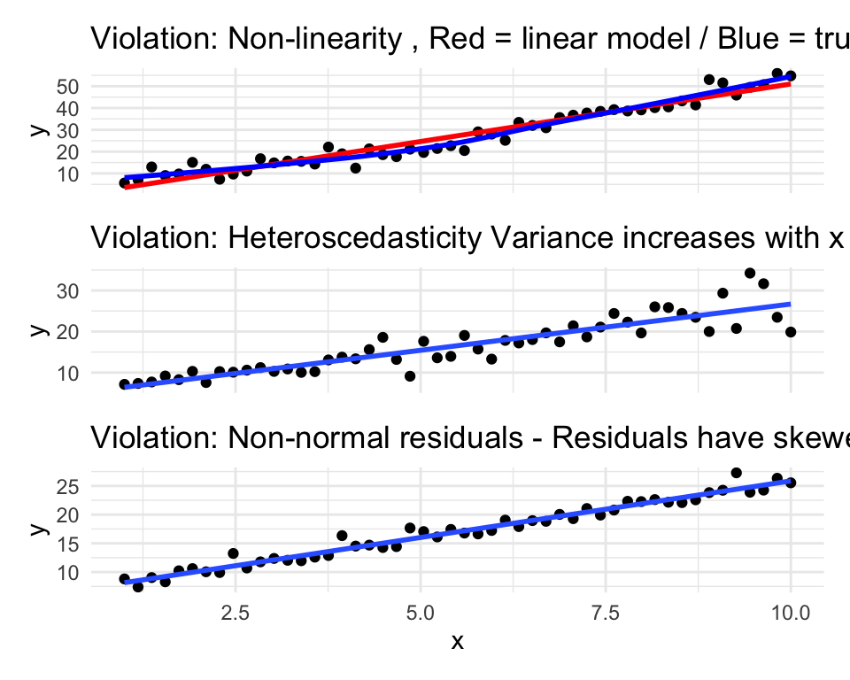

# **Lecture 9:** Linear Regression - estimates of error and significance

- Estimates of standard error and confidence intervals for slow and intercept to determine confidence bands
- the 95% confidence band will contain the true population line 95/100 under repeated sampling
- this is usually done in R

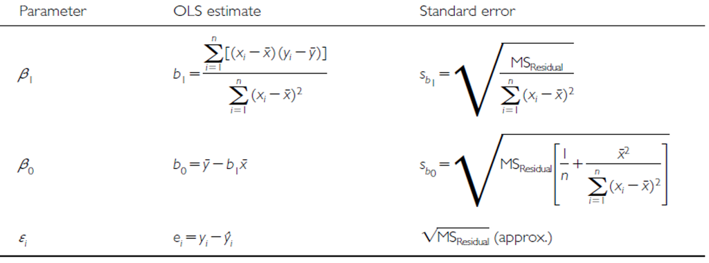

# **Lecture 9:** Linear Regression - estimates of error and significance

In addition to getting estimates of population parameters (β0 , β1), want to test hypotheses about them

- This is accomplished by analysis of variance
- Partition variance in Y: due to variation in X, due to other things (error)

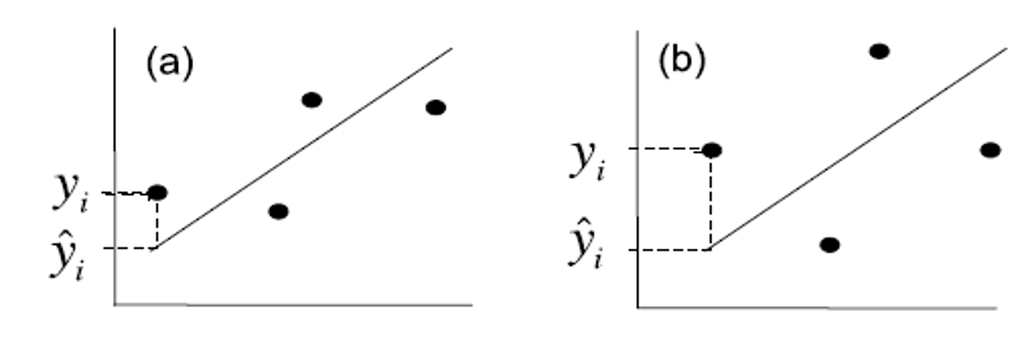

# **Lecture 9:** Linear Regression - estimates of variance

Total variation in Y is “partitioned” into 3 components:

- $SS_{regression}$: variation explained by regression
  - difference between predicted values (ŷi ) and mean y (ȳ)
  - dfs= 1 for simple linear (parameters-1)
- $SS_{residual}$: variation not explained by regression
  - difference between observed ($y_i$) and predicted ($\hat{y}_i$) values
  - dfs= n-2
- $SS_{total}$: total variation
  - sum of squared deviations of each observation ($y_i$) from mean ($\bar{y}$)
  - dfs = n-1

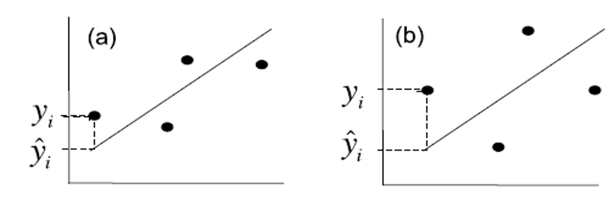

# **Lecture 9:** Linear Regression - estimates of variance

Total variation in Y is “partitioned” into 3 components:

- $SS_{regression}$: variation explained by regression
  - difference between predicted values (ŷi ) and mean y (ȳ)
  - dfs= 1 for simple linear (parameters-1)
- $SS_{residual}$: variation not explained by regression
  - difference between observed ($y_i$) and predicted ($\hat{y}_i$) values
  - dfs= n-2
- $SS_{total}$: total variation
  - sum of squared deviations of each observation ($y_i$) from mean ($\bar{y}$)
  - dfs = n-1

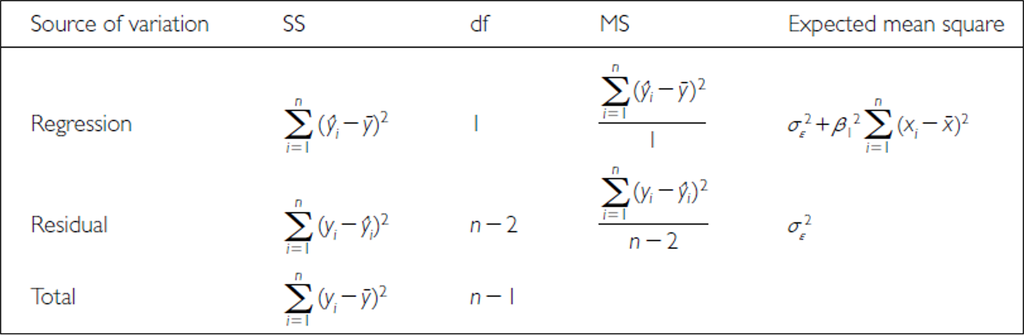

# **Lecture 9:** Linear Regression - estimates of variance

Total variation in Y is “partitioned” into 3 components:

- $SS_{regression}$: variation explained by regression
  - GREATER IN C than D
- $SS_{residual}$: variation not explained by regression
  - GREATER IN B THAN A
- $SS_{total}$: total variation

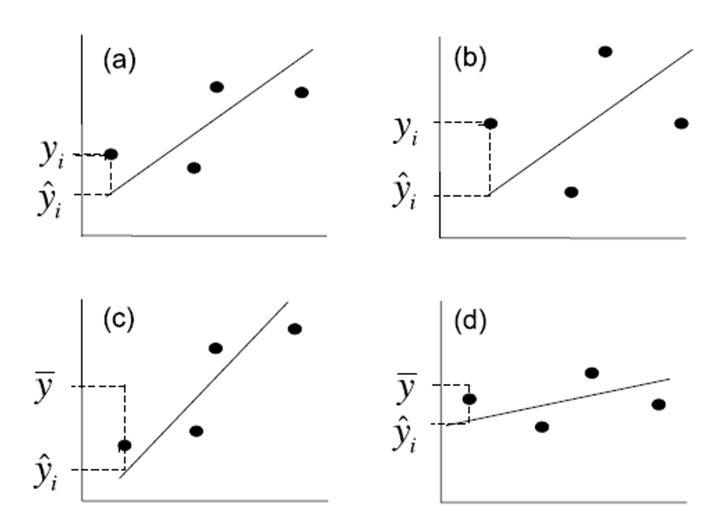

# **Lecture 9:** Linear Regression - estimates of variance

Sums of Squares and degress of freedome are:

$SS_{regression} +SS_{residual} = SS_{total}$

$df_{regression}+df_{residual} = df_{total}$

- Sums of Squares depends on n
- We need a different estimate of variance

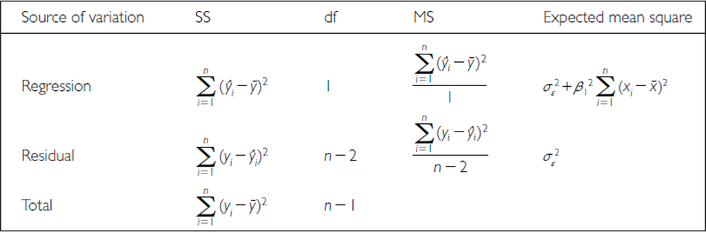

# **Lecture 9:** Linear Regression - estimates of variance

Sums of Squares converted to Mean Squares

- Sums of Squares divided by degrees of freedom - does not depend on n
- $MS_{residual}$: estimate population variation
- $MS_{regression}$: estimate pop variation and variation due to X-Y relationship
- Mean Squares are not additive

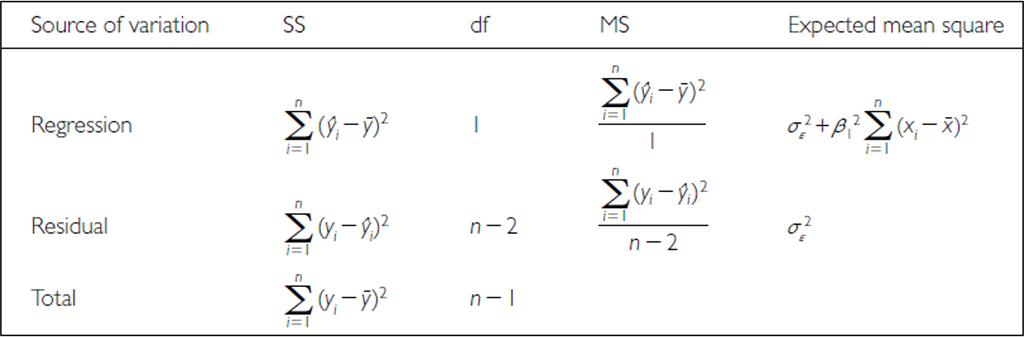

Back to top